# Algunos genotipos de trigo duro sostienen su fotosíntesis bajo calor

Borrador con storytelling — datos simulados

Autor/a

Paul López

Fecha de publicación

26 de octubre de 2026

**Advertencia**

**Todos los datos son simulados.** Están inspirados en una tesis sobre trigo duro (*Triticum durum*) bajo calor en antesis, pero no son mediciones reales ni resultados de esa tesis. El análisis es descriptivo.

## El calor en floración amenaza al trigo duro

Las olas de calor durante la antesis reducen la fotosíntesis y el rendimiento del trigo. Si algunos genotipos toleran mejor el calor, se pueden priorizar en mejoramiento.

**Pregunta:** ¿todos los genotipos sufren igual bajo calor, o algunos sostienen su fotosíntesis? ¿Qué cambia en sus nutrientes y metabolitos?

**Diseño:** 40 muestras = 5 genotipos (G1–G5) × 2 tratamientos (Control, Calor) × 4 bloques. Por cada muestra hay tres capas de datos: fisiología, ionómica y metabolómica.

## El calor reduce la fotosíntesis neta un 43,1 %

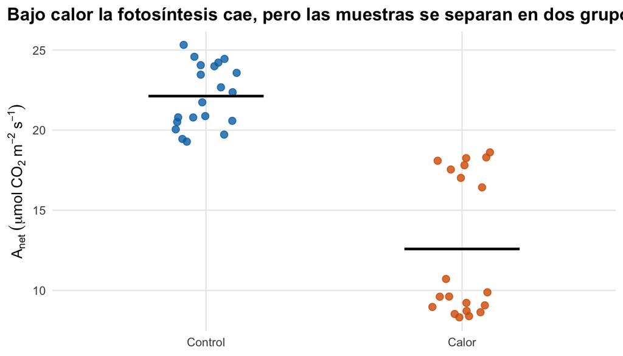

Figura 1: Fotosíntesis neta por tratamiento. Cada punto es una muestra (n = 20 por tratamiento); la barra negra es la media.

La media pasa de 22,1 a 12,6 µmol CO₂ m⁻² s⁻¹. Pero la nube de puntos bajo calor se ve partida en dos grupos: eso sugiere que los genotipos no responden igual.

## G1 y G3 sostienen casi el doble de fotosíntesis que el resto

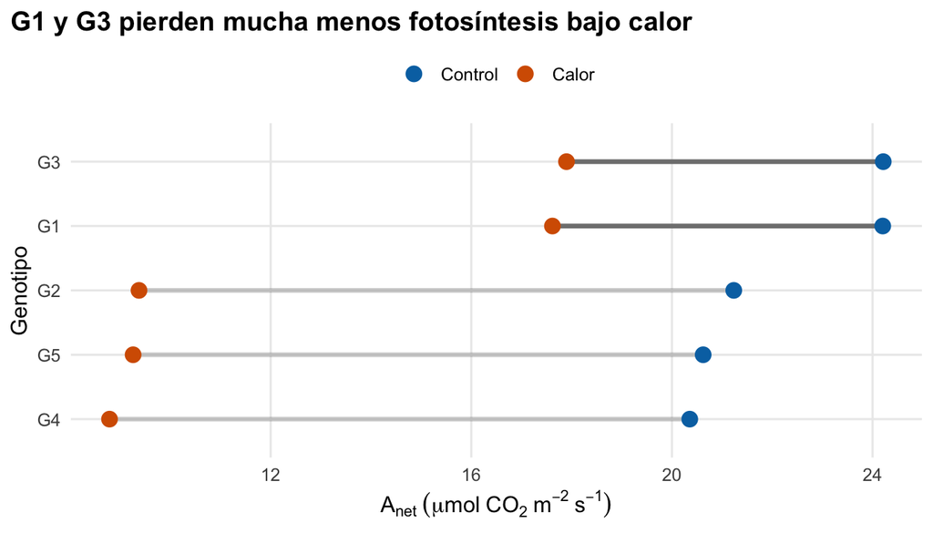

Figura 2: Media de fotosíntesis neta por genotipo en control y calor (n = 4 por combinación). Las líneas unen el mismo genotipo.

Bajo calor, G1 y G3 mantienen 17,6–17,9 µmol CO₂ m⁻² s⁻¹, mientras que G2, G4 y G5 caen a 8,8–9,4. En control los cinco genotipos estaban más próximos.

## El potasio baja un 21,2 % y la prolina sube un 57,6 %

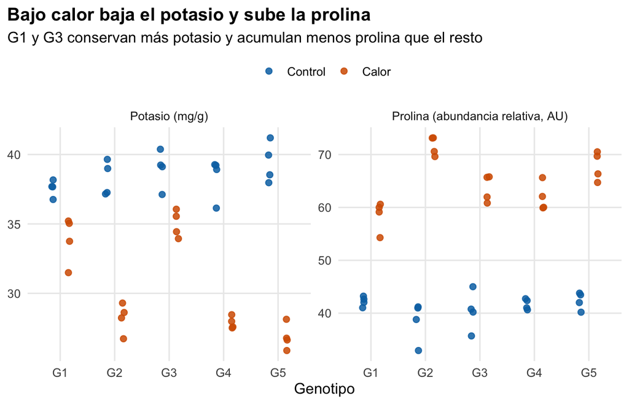

Figura 3: Potasio y prolina por genotipo y tratamiento. Cada punto es una muestra (n = 4 por combinación).

## Bajo calor, las muestras con más potasio tienen más fotosíntesis

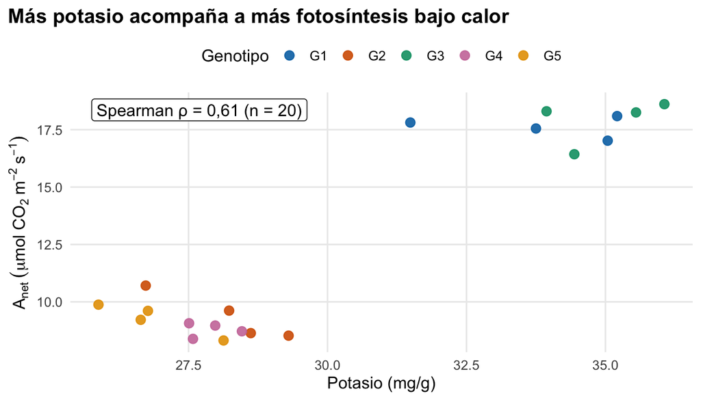

Figura 4: Fotosíntesis neta frente a potasio en las muestras bajo calor (n = 20). Color por genotipo.

La asociación es moderada (ρ = 0,61) y en buena parte refleja la diferencia entre genotipos: G1 y G3 aparecen arriba a la derecha. No permite afirmar que el potasio *cause* la fotosíntesis más alta.

## Mensaje final: hay genotipos más tolerantes, y el potasio es una pista

- El calor reduce la fotosíntesis neta (−43,1 %) y el potasio (−21,2 %), y aumenta la prolina (+57,6 %).
- **G1 y G3** sostienen casi el doble de fotosíntesis que el resto bajo calor. Son candidatos a estudiar.
- La relación entre potasio y fotosíntesis sugiere una hipótesis para probar en un experimento: que el mantenimiento del potasio contribuya a la tolerancia.

### Limitaciones

- **Datos simulados:** sirven para practicar el análisis, no para sacar conclusiones agronómicas.
- **Análisis descriptivo:** no hay pruebas de hipótesis ni modelos que consideren el bloque.
- **n pequeño:** 4 muestras por genotipo y tratamiento.
- **Correlación ≠ causalidad:** la asociación entre potasio y fotosíntesis puede deberse al genotipo.

### Próximos pasos

Ajustar un modelo mixto (tratamiento × genotipo, con bloque como efecto aleatorio) y hacer un PCA de las tres capas para ver si G1 y G3 se separan también en el perfil metabólico.